```python
from keras.datasets import mnist
import numpy as np
import matplotlib.pyplot as plt
from random import sample
from sklearn.preprocessing import MinMaxScaler
from sklearn.ensemble import RandomForestClassifier
from sklearn.model_selection import KFold
from sklearn.metrics import accuracy_score, confusion_matrix
```

# PCA - Part 1

Prepare the dataset to perform PCA. It basically selects 1000 images to perform classification. Before classification, we need to perform PCA to reduce dimensionality. Therefore, we need to convert images to 1D array.

```python
# Load the MNIST dataset
(x_train, y_train), (x_test, y_test) = mnist.load_data()

# Select a random subset of images for each digit
images = []
labels = []
for digit in range(10):
    digit_indices = np.where(y_train == digit)[0]
    selected_indices = sample(list(digit_indices), 100)  # Select 100 random images for each digit
    for index in selected_indices:
        images.append(x_train[index])
        labels.append(y_train[index])

images_array = np.array(images)
labels_array = np.array(labels)

# Reshape images to 1D array
images_1D_array = images_array.reshape((-1, images_array.shape[1] * images_array.shape[2]))
```

Define PCA function. It takes the reshaped dataset. It basically centers the data matrix by subtracting mean. Then, it performs SVD to get eigenvalues and eigenvectors. It sorts eigenvalues and the corresponding eigenvectors.

```python
def pca(X):
    # Compute the mean of each column
    mean = np.mean(X, axis=0)

    # Center the data by subtracting the mean from each column
    centered_data = X - mean

    # Perform Singular Value Decomposition (SVD) directly on the centered data matrix
    eigen_vectors,eigen_values,v = np.linalg.svd(centered_data.T)

    # Sort the eigenvalues in descending order
    sorted_index = np.argsort(eigen_values)[::-1]
    sorted_eigenvalue = eigen_values[sorted_index]
    sorted_eigenvectors = eigen_vectors[:,sorted_index]

    # Return the mean, eigenvalues (weights), and eigenvectors (vectors)
    return mean, sorted_eigenvalue, sorted_eigenvectors
```

Perform PCA with the given dataset

```python
mean, eigenvalues, eigenvectors = pca(images_1D_array) # mean, weights and vectors
```

Try with 10 components. It gets the first 10 components and performs dot product to project dataset onto the components. Then, it reconstructs dataset to show the results as an image.

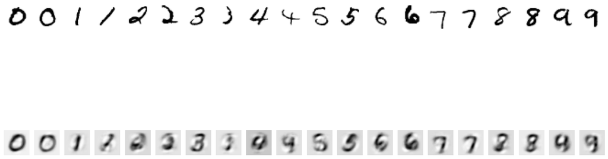

```python
num_components = 10

# Get the components
components = eigenvectors[:, :num_components]

# Project data onto the components
projected_data=np.dot(images_1D_array-mean,components)

# Reconstruct the data
reconstructed_data = np.dot(projected_data, components.T) + mean

# Reshape the reconstructed images
original_images = images_array
reconstructed_images = reconstructed_data.reshape((-1, x_train.shape[1], x_train.shape[2]))

# Display the images
plt.figure(figsize=(20, 6))
for i in range(20):
    # Original images
    plt.subplot(3, 20, i + 1)
    plt.imshow(original_images[i*50], cmap='Greys')
    plt.axis('off')

    # Reconstructed images
    plt.subplot(3, 20, i + 41)
    plt.imshow(reconstructed_images[i*50], cmap='Greys')
    plt.axis('off')

plt.show()

reconstructed_data_10 = reconstructed_data
```

Try with 20 components

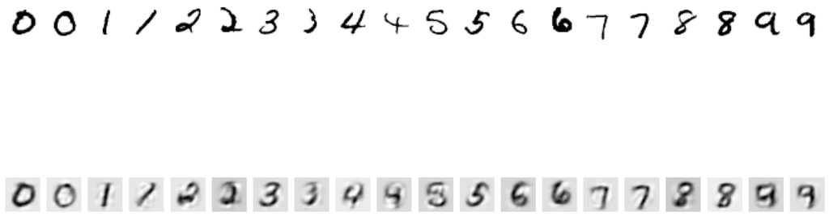

```python
num_components = 20

# Get the components
components = eigenvectors[:, :num_components]

# Project data onto the components
projected_data=np.dot(images_1D_array-mean,components)

# Reconstruct the data
reconstructed_data = np.dot(projected_data, components.T) + mean

# Reshape the reconstructed images
original_images = images_array
reconstructed_images = reconstructed_data.reshape((-1, x_train.shape[1], x_train.shape[2]))

# Display the images
plt.figure(figsize=(20, 6))
for i in range(20):
    # Original images
    plt.subplot(3, 20, i + 1)
    plt.imshow(original_images[i*50], cmap='Greys')
    plt.axis('off')

    # Reconstructed images
    plt.subplot(3, 20, i + 41)
    plt.imshow(reconstructed_images[i*50], cmap='Greys')
    plt.axis('off')

plt.show()

reconstructed_data_20 = reconstructed_data
```

Try with 50 components

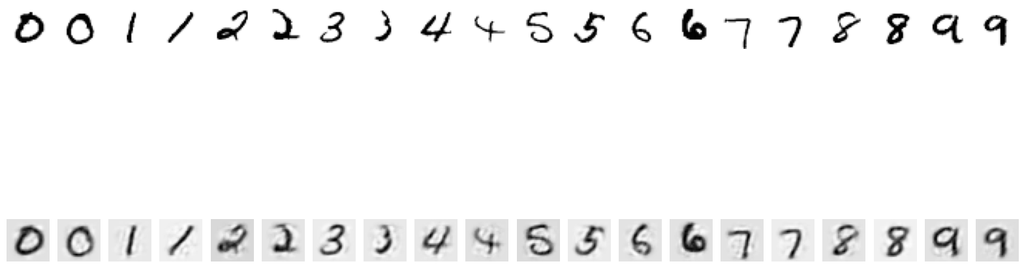

```python
num_components = 50

# Get the components
components = eigenvectors[:, :num_components]

# Project data onto the components
projected_data=np.dot(images_1D_array-mean,components)

# Reconstruct the data
reconstructed_data = np.dot(projected_data, components.T) + mean

# Reshape the reconstructed images
original_images = images_array
reconstructed_images = reconstructed_data.reshape((-1, x_train.shape[1], x_train.shape[2]))

# Display the images
plt.figure(figsize=(20, 6))
for i in range(20):
    # Original images
    plt.subplot(3, 20, i + 1)
    plt.imshow(original_images[i*50], cmap='Greys')
    plt.axis('off')

    # Reconstructed images
    plt.subplot(3, 20, i + 41)
    plt.imshow(reconstructed_images[i*50], cmap='Greys')
    plt.axis('off')

plt.show()

reconstructed_data_50 = reconstructed_data
```

Try with 100 components

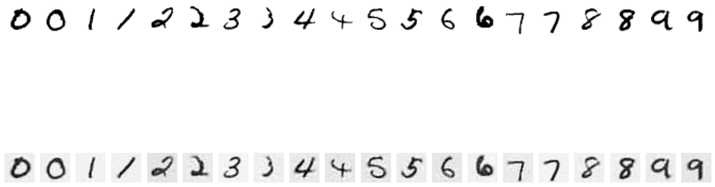

```python
num_components = 100

# Get the components
components = eigenvectors[:, :num_components]

# Project data onto the components
projected_data=np.dot(images_1D_array-mean,components)

# Reconstruct the data
reconstructed_data = np.dot(projected_data, components.T) + mean

# Reshape the reconstructed images
original_images = images_array
reconstructed_images = reconstructed_data.reshape((-1, x_train.shape[1], x_train.shape[2]))

# Display the images
plt.figure(figsize=(20, 6))
for i in range(20):
    # Original images
    plt.subplot(3, 20, i + 1)
    plt.imshow(original_images[i*50], cmap='Greys')
    plt.axis('off')

    # Reconstructed images
    plt.subplot(3, 20, i + 41)
    plt.imshow(reconstructed_images[i*50], cmap='Greys')
    plt.axis('off')

plt.show()

reconstructed_data_100 = reconstructed_data
```

Try with 200 components

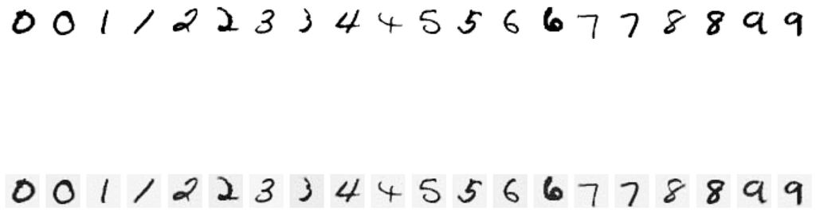

```python
num_components = 200

# Get the components
components = eigenvectors[:, :num_components]

# Project data onto the components
projected_data=np.dot(images_1D_array-mean,components)

# Reconstruct the data
reconstructed_data = np.dot(projected_data, components.T) + mean

# Reshape the reconstructed images
original_images = images_array
reconstructed_images = reconstructed_data.reshape((-1, x_train.shape[1], x_train.shape[2]))

# Display the images
plt.figure(figsize=(20, 6))
for i in range(20):
    # Original images
    plt.subplot(3, 20, i + 1)
    plt.imshow(original_images[i*50], cmap='Greys')
    plt.axis('off')

    # Reconstructed images
    plt.subplot(3, 20, i + 41)
    plt.imshow(reconstructed_images[i*50], cmap='Greys')
    plt.axis('off')

plt.show()

reconstructed_data_200 = reconstructed_data
```

We get better results when we use more components because each component carries some variance and the more components we use, the more accurate results we get.

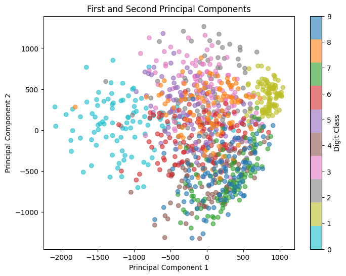

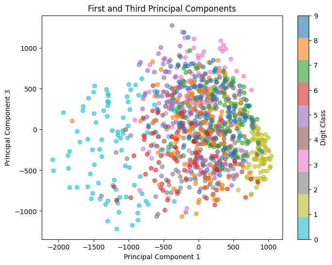

```python
# Get the first and second PCs from the projected data
X_pc1 = projected_data[:, 0]
X_pc2 = projected_data[:, 1]

# Plotting the data points on the first and second principal components
plt.figure(figsize=(8, 6))
scatter = plt.scatter(X_pc1, X_pc2, c=labels_array, cmap='tab10_r', alpha=0.6)
plt.xlabel('Principal Component 1')
plt.ylabel('Principal Component 2')
plt.title('First and Second Principal Components')
plt.colorbar(scatter, label='Digit Class')
plt.show()

# Get the first and third PCs from the projected data
X_pc1 = projected_data[:, 0]
X_pc3 = projected_data[:, 2]

# Plotting the data points on the first and third principal components
plt.figure(figsize=(8, 6))
scatter = plt.scatter(X_pc1, X_pc3, c=labels_array, cmap='tab10_r', alpha=0.6)
plt.xlabel('Principal Component 1')
plt.ylabel('Principal Component 3')
plt.title('First and Third Principal Components')
plt.colorbar(scatter, label='Digit Class')
plt.show()
```

We can see that there are some clusters since the images belonging to the same class have similar structures and this will create clusters. Some classes have similar positions on the plot. If their structures are similar, this might create such a result. The most distinct digits are 0 and 1 because we can see them as separate from the others in two cases.

# Classification - Part 2

```python
# Initialize RandomForestClassifier
rf_classifier = RandomForestClassifier(random_state=42)
```

Perform classification with the data - 10 components

```
Fold 1 is completed
Fold 2 is completed
Fold 3 is completed
Fold 4 is completed
Fold 5 is completed
Average Accuracy: 0.84
```

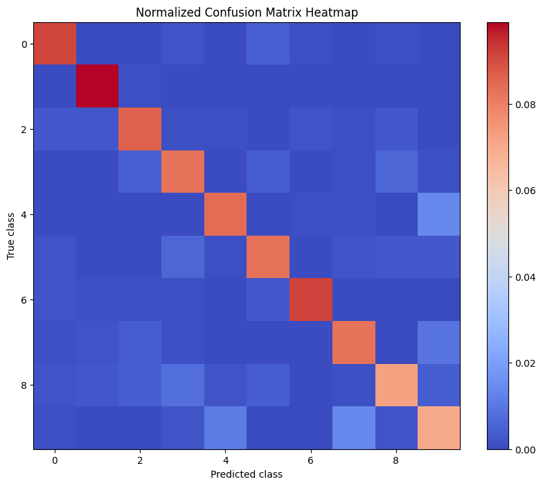

```python
kf = KFold(n_splits=5, shuffle=True, random_state=42)

# initialize performance metrics
accuracies = []
confusion_matrices = []
count = 1

# iterate over each fold
for train_index, test_index in kf.split(reconstructed_data_10, labels_array):
    # split data into training and testing sets
    X_train, X_test = reconstructed_data_10[train_index], reconstructed_data_10[test_index]
    y_train, y_test = labels_array[train_index], labels_array[test_index]

    # train the model
    rf_classifier.fit(X_train, y_train)
    # predict the result
    y_pred = rf_classifier.predict(X_test)

    # calculate accuracy
    accuracy = accuracy_score(y_test, y_pred)
    accuracies.append(accuracy)

    # calculate confusion matrix
    conf_matrix = confusion_matrix(y_test, y_pred, labels=np.unique(labels_array))
    confusion_matrices.append(conf_matrix)

    print(f"Fold {count} is completed")
    count += 1


# calculate average accuracy
average_accuracy = np.mean(accuracies)

# calculate average confusion matrix and normalized version
average_conf_matrix = np.mean(confusion_matrices, axis=0)

normalized_conf_matrix = average_conf_matrix / np.sum(average_conf_matrix)

# print the result
print(f'Average Accuracy: {average_accuracy:.2f}')

# create a heatmap for the normalized confusion matrix
plt.figure(figsize=(10, 8))

cmap = plt.get_cmap('coolwarm')
heatmap = plt.imshow(normalized_conf_matrix, cmap=cmap)
plt.colorbar(heatmap)
plt.xlabel('Predicted class')
plt.ylabel('True class')
plt.title('Normalized Confusion Matrix Heatmap')

# show the plot
plt.show()
```

Perform classification with the data - 20 components

```
Fold 1 is completed
Fold 2 is completed
Fold 3 is completed
Fold 4 is completed
Fold 5 is completed
Average Accuracy: 0.91
```

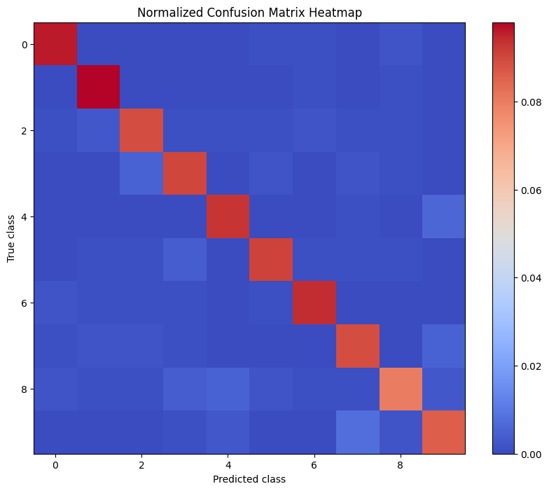

```python
kf = KFold(n_splits=5, shuffle=True, random_state=42)

# initialize performance metrics
accuracies = []
confusion_matrices = []
count = 1

# iterate over each fold
for train_index, test_index in kf.split(reconstructed_data_20, labels_array):
    # split data into training and testing sets
    X_train, X_test = reconstructed_data_20[train_index], reconstructed_data_20[test_index]
    y_train, y_test = labels_array[train_index], labels_array[test_index]

    # train the model
    rf_classifier.fit(X_train, y_train)
    # predict the result
    y_pred = rf_classifier.predict(X_test)

    # calculate accuracy
    accuracy = accuracy_score(y_test, y_pred)
    accuracies.append(accuracy)

    # calculate confusion matrix
    conf_matrix = confusion_matrix(y_test, y_pred, labels=np.unique(labels_array))
    confusion_matrices.append(conf_matrix)

    print(f"Fold {count} is completed")
    count += 1


# calculate average accuracy
average_accuracy = np.mean(accuracies)

# calculate average confusion matrix and normalized version
average_conf_matrix = np.mean(confusion_matrices, axis=0)

normalized_conf_matrix = average_conf_matrix / np.sum(average_conf_matrix)

# print the result
print(f'Average Accuracy: {average_accuracy:.2f}')

# create a heatmap for the normalized confusion matrix
plt.figure(figsize=(10, 8))

cmap = plt.get_cmap('coolwarm')
heatmap = plt.imshow(normalized_conf_matrix, cmap=cmap)
plt.colorbar(heatmap)
plt.xlabel('Predicted class')
plt.ylabel('True class')
plt.title('Normalized Confusion Matrix Heatmap')

# show the plot
plt.show()
```

Perform classification with the data - 50 components

```
Fold 1 is completed
Fold 2 is completed
Fold 3 is completed
Fold 4 is completed
Fold 5 is completed
Average Accuracy: 0.91
```

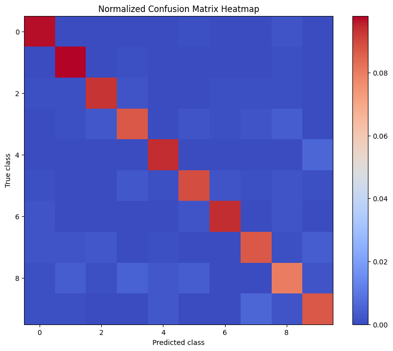

```python
kf = KFold(n_splits=5, shuffle=True, random_state=42)

# initialize performance metrics
accuracies = []
confusion_matrices = []
count = 1

# iterate over each fold
for train_index, test_index in kf.split(reconstructed_data_50, labels_array):
    # split data into training and testing sets
    X_train, X_test = reconstructed_data_50[train_index], reconstructed_data_50[test_index]
    y_train, y_test = labels_array[train_index], labels_array[test_index]

    # train the model
    rf_classifier.fit(X_train, y_train)
    # predict the result
    y_pred = rf_classifier.predict(X_test)

    # calculate accuracy
    accuracy = accuracy_score(y_test, y_pred)
    accuracies.append(accuracy)

    # calculate confusion matrix
    conf_matrix = confusion_matrix(y_test, y_pred, labels=np.unique(labels_array))
    confusion_matrices.append(conf_matrix)

    print(f"Fold {count} is completed")
    count += 1


# calculate average accuracy
average_accuracy = np.mean(accuracies)

# calculate average confusion matrix and normalized version
average_conf_matrix = np.mean(confusion_matrices, axis=0)

normalized_conf_matrix = average_conf_matrix / np.sum(average_conf_matrix)

# print the result
print(f'Average Accuracy: {average_accuracy:.2f}')

# create a heatmap for the normalized confusion matrix
plt.figure(figsize=(10, 8))

cmap = plt.get_cmap('coolwarm')
heatmap = plt.imshow(normalized_conf_matrix, cmap=cmap)
plt.colorbar(heatmap)
plt.xlabel('Predicted class')
plt.ylabel('True class')
plt.title('Normalized Confusion Matrix Heatmap')

# show the plot
plt.show()
```

Perform classification with the data - 100 components

```
Fold 1 is completed
Fold 2 is completed
Fold 3 is completed
Fold 4 is completed
Fold 5 is completed
Average Accuracy: 0.88
```

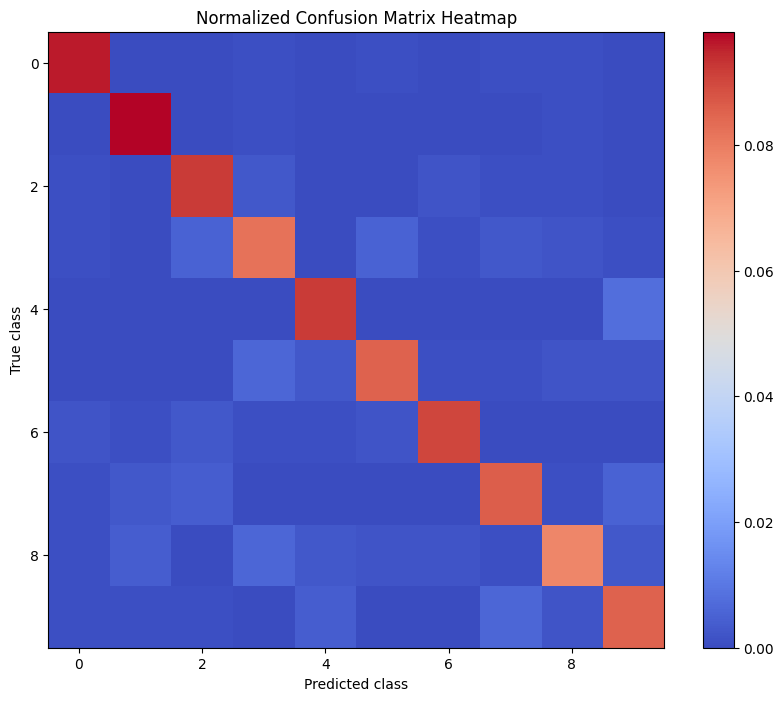

```python
kf = KFold(n_splits=5, shuffle=True, random_state=42)

# initialize performance metrics
accuracies = []
confusion_matrices = []
count = 1

# iterate over each fold
for train_index, test_index in kf.split(reconstructed_data_100, labels_array):
    # split data into training and testing sets
    X_train, X_test = reconstructed_data_100[train_index], reconstructed_data_100[test_index]
    y_train, y_test = labels_array[train_index], labels_array[test_index]

    # train the model
    rf_classifier.fit(X_train, y_train)
    # predict the result
    y_pred = rf_classifier.predict(X_test)

    # calculate accuracy
    accuracy = accuracy_score(y_test, y_pred)
    accuracies.append(accuracy)

    # calculate confusion matrix
    conf_matrix = confusion_matrix(y_test, y_pred, labels=np.unique(labels_array))
    confusion_matrices.append(conf_matrix)

    print(f"Fold {count} is completed")
    count += 1


# calculate average accuracy
average_accuracy = np.mean(accuracies)

# calculate average confusion matrix and normalized version
average_conf_matrix = np.mean(confusion_matrices, axis=0)

normalized_conf_matrix = average_conf_matrix / np.sum(average_conf_matrix)

# print the result
print(f'Average Accuracy: {average_accuracy:.2f}')

# create a heatmap for the normalized confusion matrix
plt.figure(figsize=(10, 8))

cmap = plt.get_cmap('coolwarm')
heatmap = plt.imshow(normalized_conf_matrix, cmap=cmap)
plt.colorbar(heatmap)
plt.xlabel('Predicted class')
plt.ylabel('True class')
plt.title('Normalized Confusion Matrix Heatmap')

# show the plot
plt.show()
```

Perform classification with the data - 200 components

```
Fold 1 is completed
Fold 2 is completed
Fold 3 is completed
Fold 4 is completed
Fold 5 is completed
Average Accuracy: 0.88
```

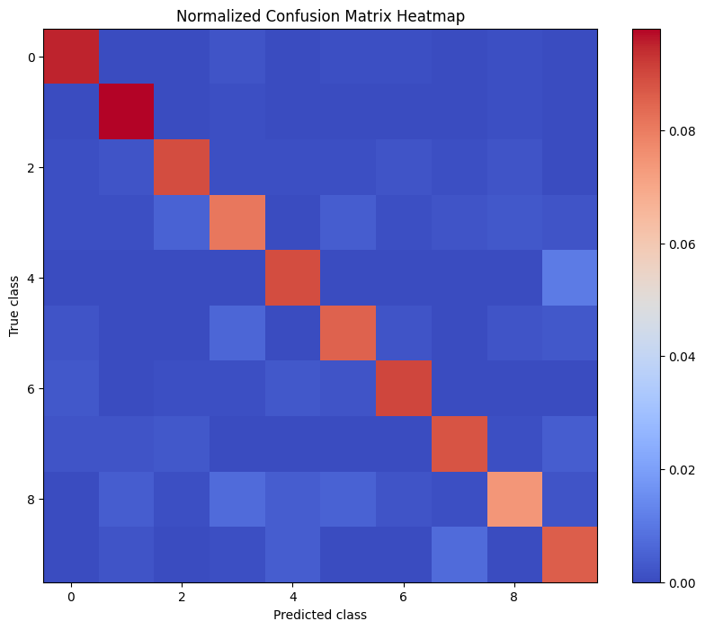

```python
kf = KFold(n_splits=5, shuffle=True, random_state=42)

# initialize performance metrics
accuracies = []
confusion_matrices = []
count = 1

# iterate over each fold
for train_index, test_index in kf.split(reconstructed_data_200, labels_array):
    # split data into training and testing sets
    X_train, X_test = reconstructed_data_200[train_index], reconstructed_data_200[test_index]
    y_train, y_test = labels_array[train_index], labels_array[test_index]

    # train the model
    rf_classifier.fit(X_train, y_train)
    # predict the result
    y_pred = rf_classifier.predict(X_test)

    # calculate accuracy
    accuracy = accuracy_score(y_test, y_pred)
    accuracies.append(accuracy)

    # calculate confusion matrix
    conf_matrix = confusion_matrix(y_test, y_pred, labels=np.unique(labels_array))
    confusion_matrices.append(conf_matrix)

    print(f"Fold {count} is completed")
    count += 1


# calculate average accuracy
average_accuracy = np.mean(accuracies)

# calculate average confusion matrix and normalized version
average_conf_matrix = np.mean(confusion_matrices, axis=0)

normalized_conf_matrix = average_conf_matrix / np.sum(average_conf_matrix)

# print the result
print(f'Average Accuracy: {average_accuracy:.2f}')

# create a heatmap for the normalized confusion matrix
plt.figure(figsize=(10, 8))

cmap = plt.get_cmap('coolwarm')
heatmap = plt.imshow(normalized_conf_matrix, cmap=cmap)
plt.colorbar(heatmap)
plt.xlabel('Predicted class')
plt.ylabel('True class')
plt.title('Normalized Confusion Matrix Heatmap')

# show the plot
plt.show()
```

The result is that 10 component version is not sufficient to represent the dataset because it has the lowest accuracy. The best accuracy belongs to 20 and 50 component versions. We can see that there is a decrese after 50 components. Both 100 and 200 have 0.88 accuracy. Therefore, the optimal component number among the tested ones is between 20-50.

When we look at the confusion matrix, the classes 0 and 1 have higher accuracy. The class 8 has the lowest accuracy for many matrices.